# utiliser_nsu_outils

## Installation

Avant de lancer ce programme pour la première fois, (re)installer les logiciels suivants:

- R
- RTools
- RStudio

Même si ces logiciels ont été déjà installés (e.g., lors d’une vague antérieure d’EHCVM), il faut réinstaller afin d’avoir une version récente d ces outils pour que le programme marche avec succès.

Veuillez lire ici-bas comment obtenir et installer ces logiciels

### R

- Suivre ce [lien](https://cran.r-project.org/)
- Cliquer sur le lien approprié pour votre système d’exploitation
- Cliquer sur `base`
- Télécharger et installer (e.g., [ceci](https://cran.r-project.org/bin/windows/base/R-4.1.1-win.exe) pour Windows)

### RTools

Nécessaire pour le système d’exploitation Windows

- Suivre ce [lien](https://cran.r-project.org/)
- Cliquer sur `Windows`
- Cliquer sur `RTools`
- Télécharger et installer (e.g., [ceci](https://cran.r-project.org/bin/windows/Rtools/rtools40v2-x86_64.exe) pour un système 64)

Ce programme permet à R de compiler des scripts C++ utilisés par certains packages (e.g., `{dplyr}`).

### RStudio

- Suivre ce [lien](https://www.rstudio.com/products/rstudio/)
- Sélectionner RStudio Desktop puis Open Source Edition
- Cliquer sur le lien approprié pour votre système d’exploitation
- Télécharger et installer (e.g., [ceci](https://www.rstudio.com/products/rstudio/download/#download) pour Windows)

### Ce programme

- Obtenir une copie du répositoire
  - Naviguer vers [ce répositoire](https://github.com/arthur-shaw/utiliser_nsu_outils)
  - Cliquer sur le bouton `Code`
  - Cliquer sur `Download ZIP`
  - Télécharger vers le répertoire voulu sur votre machine

[figure not shown]

- Décomprimer le fichier zip

## Emploi

### Mise en place de fichiers d’entrée

Ce programme organise les fichiers comme suit:

```
#> .
#> +-- consommation
#> |   +-- entree
#> |   |   +-- donnees
#> |   |   \-- images
#> |   \-- sortie
#> |       +-- donnees
#> |       \-- images
#> +-- docs
#> +-- production
#> |   +-- entree
#> |   \-- sortie
#> \-- renv
#>     +-- library
#>     |   \-- R-4.0
#>     +-- local
#>     \-- staging
```

Pour que le programme produit des sorties, il faut lui fournir des inputs: des données et des images.

Pour les NSU de consommation, mettre:

- Données dans `consommation/entree/donnees`
- Images dans `consommation/entree/images`

Pour les NSU de production, mettre les données dans `production/entree/`.

Dans les deux cas, décomprimer chaque fichier zip pour que le contenu occupe un dossier à lui. Par exemple:

[figure not shown]

### Adaptations du programme

1. Modifier Modifier le lien vers votre programme
2. Spécifier les composants d’une strate
3. Modifier `dir_regexp` pour les fichiers de production

#### Modifier le lien vers votre programme

La variable `projet_dir`, en tête de programme, le répertoire où trouver ce programme sur votre machine. Modifier ce chemin pour refleter votre situation.

```r
# =============================================================================
# Fournir les répertoires
# =============================================================================

projet_dir <- "C:/EHCVM/NSU/"                     # où se trouve le projet
```

En ce faisant, faire attention à deux points importants:

1. Employer des slashs au lieu d’anti-slashs. Par exemple: ceci `"C:/EHCVM/NSU/"` plutôt que celà `"C:\EHCVM\NSU\"`.
2. Mettre un slash à la fin du chemin. Par exemple: ceci `"C:/EHCVM/NSU/"` plutôt que celà `"C:/EHCVM/NSU"`.

Pour modifier le programme:

- Ouvrir RStudio
- Ouvrir le fichier `fusionner_et_classer_nsu.R`
- Modifier la valeur de la variable `projet_dir`
- Sauvegarder le programme

#### Spécifier les composants d’une strate

Des répertoires seront créés par produit-unité-strate. Pour définir les strates d’intérêt de l’enquête, fournir une vecteur de nom de variables qui, ensemblent, forment les strates de l’échantillon NSU.

En de termes concrets, modifier la valeur de la variable `variables_strate`. L’exemple ici-bas montre le cas, assez fréquent, de strates composés par la région (`s00q01`) et le milieu (`s00q04`).

```r
# =============================================================================
# Définir les strates
# =============================================================================

# Mettre les variables qui, ensemble, définissent les strates
# Les valeurs serviront à créer des sous-répertoires strates au sein de chaque
# répertoire de produit-unité observé
# - en cas de plusieurs variables, formuler comme suit: c("var1", "var2")
# - en cas d'une seule variable formuler comme un texte: "var1"
variables_strate <- c("s00q01", "s00q04")
```

#### Modifier `dir_regexp` pour les fichiers de production

Les fonctions `combine_nsu_data` et `combine_market_data` ont besoin d’un paramètre `dir_regexp` afin d’indentifier les répertoires qui contiennent les données de production. Il s’agit d’un texte qui se trouve dans le nom de tous les répertoires d’intérêt. Par défaut, la valeur est `"_production_"`. Si votre situation est différente, mettre un texte qui se trouve à l’intérieur du nom des répertoires avec des données de production.

```r
# =============================================================================
# NSU de production
# =============================================================================

nsuoutils::combine_nsu_data(
    dir_in = nsu_prod_entree,
    dir_regexp = "_production_", # NOTEZ BIEN: modifier selon votre situation
    data_type = "production",
    dir_out = nsu_prod_sortie
)

# Fusionner les observations au niveau des marchés
nsuoutils::combine_market_data(
    dir_in = nsu_prod_entree,
    dir_regexp = "_production_", # NOTEZ BIEN: modifier selon votre situation
    data_type = "production",
    dir_out = nsu_prod_sortie
)
```

### Lancer

Une fois les préparatifs ci-haut terminés, il est temps de lancer le programme. Pour ce faire:

- Ouvrir RStudio
- Ouvrir le fichier `utiliser_nsu_outils.Rproj` qui aura l’effet de fournir les ressources du projet
- Ouvrir le fichier `fusionner_et_classer_nsu.R` que vous avez modifié plus haut
- Lancer le programme
- Accepter de mettre à jour les packages

Après avoir ouvert le fichier `utiliser_nsu_outils.Rproj`, RStudio affichera un message comme suit, indiquant que:

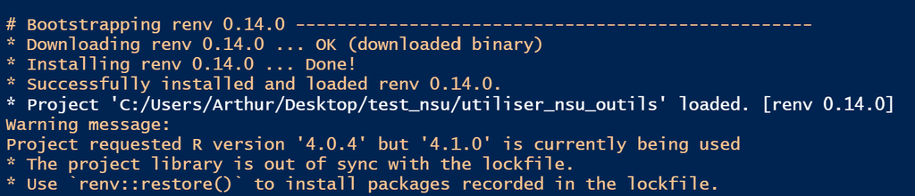

- Le package `{renv}`, qui est reponsable contrôles la version des packages chez tous les utilisateurs, a été installé
- La version de R installée sur votre machine soit est soit n’est pas en en phase avec la version indiqué dans le fichier de contrôle de version.

Si votre version de R n’est pas en accord avec la version de R attendu, veuillez installer la version convenue. S’il s’agit d’une plus ancienne version de R, il faut aller la chercher sur CRAN:

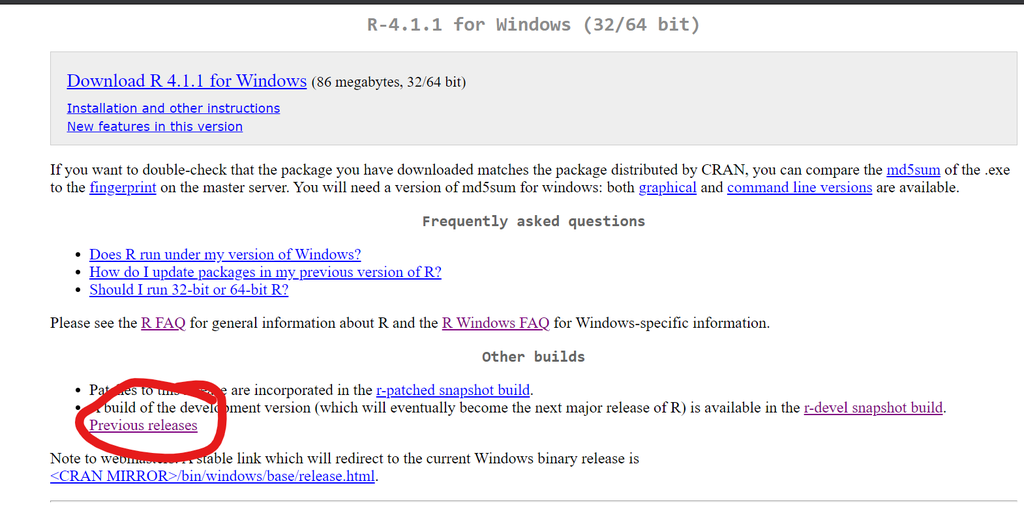

- Chercher, obtenir, et installer la version convenue (e.g., 4.0.4)

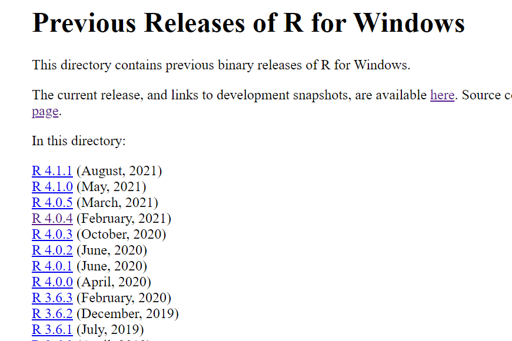

Lors du premier lancement du, RStudio demandera si vous voulez adopter les packages demandé pour ce projet, comme indiqué ici-bas.

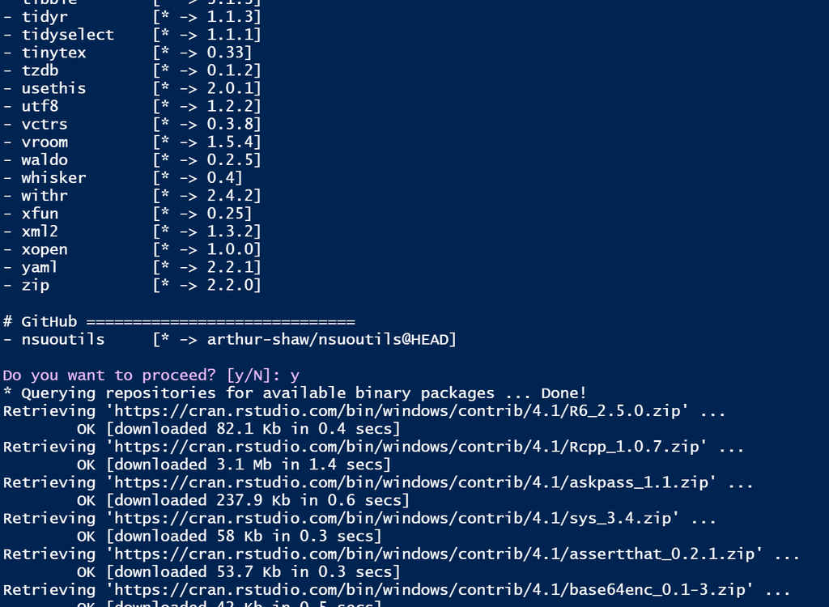

Taper `y` dans la console de RStudio. Ceci créera un répertoire pour ce projet dont les versions des packages s’accorderont avec ce qui est jugé nécessaire pour le bon déroulement du programme. Ceci n’aura pas d’effet sur les versions des packages installées sur votre machine. Pour en savoir plus, regarder la documentation de `{renv}` [ici](https://rstudio.github.io/renv/articles/renv.html).

### Réagir aux problèmes

Si vous disposer d’un compte GitHub, créer un issue [ici](https://github.com/arthur-shaw/nsuoutils), chez le package responsable des manipulations faites dans ce programme.

Si vous n’avez pas de compte, envoyer un message.

Dans les deux cas, tâcher de fournir un descriptif détaillé et, si possible, un exemple reproduisible. Dans le descriptif détaillé, envoyer:

- Description des étapes suivies
- Capture d’écran du message d’erreur
- Informations concernant votre séance de travail (i.e., executer la commande `sessionInfo()` et copier-coller le résultat)

Dans l’exemple reproduisible, partager les données d’entrée par un moyen sécurisé (i.e., pas GitHub).

### Afficher les images non-classées

La fonction `nsuoutils::sort_images()` tente de classer toutes les images retrouvés dans les images exportées. Mais elle ne pourra classer que les images où le nom de l’image paraît dans la base de données. Donc, certaines images ne seront pas classées.

Pour voir la liste d’images non-classées, executer la command `warnings()` après avoir exécuté la commande `nsuoutils::sort_images()`.

### Relancer des entrées plus récentes

Le programme pourra être relancé autant de fois que voulu sans poser de problème. Ceci permet aux utilisateurs de relancer le programme au fur et à mesure que de nouvelles informations sont reçues du terrain. Les données seront refusionnées, et les images seront re-classées en fonction des informations dans les bases de données et d’images, respectivement.